## Appendix C — Nonlinear Modeling of Chess Rating Growth

### C.1 Conceptual Overview

Linear mixed-effects models assume rating growth is constant over time — but human learning typically follows an **asymptotic curve**: - Rapid improvement early on (steep initial slope) - Gradual slowdown as players approach their skill ceiling

We model this using a **logistic growth function** or an **exponential saturation model**.

$$R_t = A - B \times e^{-k t}$$

where: - $R_t$: Rating at time $t$ - $A$: Asymptotic rating ceiling - $B$: Range between starting and ceiling rating - $k$: Learning rate constant

### C.2 Model Preparation

```r
library(tidyverse)
library(broom)
library(minpack.lm) # for nlsLM (robust nonlinear fitting)

rating_history_path <- "../../data/lichess_rating_history.csv"

# Load the same dataset from Appendix B
rating_summary <- read_csv(
  rating_history_path,
  show_col_types = FALSE
)

# Filter for Blitz category for consistency
rating_nl_df <- rating_summary %>%
  filter(category == "Blitz", !is.na(rating)) %>%
  group_by(user) %>%
  mutate(
    time_index = as.numeric(factor(row_number())),
    time_scaled = time_index / max(time_index)
  ) %>%
  filter(n() >= 10) %>% # ensure sufficient data
  ungroup()

# Select a few users for model fitting
target_users <- rating_nl_df %>%
  count(user) %>%
  arrange(desc(n)) %>%
  slice_head(n = 5) %>%
  pull(user)

target_users
```

```
## [1] "daaleksandrov"   "Zhigalko_Sergei" "lyxxj"           "Isaev_Anton_Val"
## [5] "Daniil1007"
```

### C.3 Fit Logistic / Exponential Models

```r
# Helper function: Fit logistic model per user
fit_growth_curve <- function(df) {
  tryCatch(
    {
      model <- nlsLM(
        rating ~ A - B * exp(-k * time_index),
        data = df,
        start = list(A = max(df$rating), B = max(df$rating) - min(df$rating), k = 0.05),
        control = nls.lm.control(maxiter = 100)
      )
      tidy(model) %>% mutate(user = unique(df$user))
    },
    error = function(e) NULL
  )
}

# Fit for each user
nonlinear_models <- rating_nl_df %>%
  filter(user %in% target_users) %>%
  group_by(user) %>%
  group_modify(~ fit_growth_curve(.x)) %>%
  ungroup()
nonlinear_models
```

```
## # A tibble: 15 × 6
##    user            term  estimate std.error statistic   p.value
##    <chr>           <chr>    <dbl>     <dbl>     <dbl>     <dbl>
##  1 Daniil1007      A       5.64      0.171     32.9   6.25e-118
##  2 Daniil1007      B       2.81      2.55       1.10  2.72e-  1
##  3 Daniil1007      k       0.114     0.142      0.807 4.20e-  1
##  4 Isaev_Anton_Val A       5.37      0.152     35.3   8.32e-136
##  5 Isaev_Anton_Val B       6.94      1.47       4.73  3.02e-  6
##  6 Isaev_Anton_Val k       0.0517    0.0158     3.28  1.12e-  3
##  7 Zhigalko_Sergei A       5.54      0.131     42.3   9.24e-207
##  8 Zhigalko_Sergei B      -5.42      1.46      -3.72  2.17e-  4
##  9 Zhigalko_Sergei k       0.0404    0.0156     2.59  9.70e-  3
## 10 daaleksandrov   A       5.48      0.0721    75.9   0
## 11 daaleksandrov   B       4.80      1.41       3.40  6.98e-  4
## 12 daaleksandrov   k       0.0395    0.0163     2.42  1.55e-  2
## 13 lyxxj           A       5.58      0.137     40.9   1.08e-183
## 14 lyxxj           B       6.63      2.65       2.50  1.25e-  2
## 15 lyxxj           k       0.116     0.0627     1.85  6.42e-  2
```

### C.4 Visualization: Fitted Curves vs. Actual Data

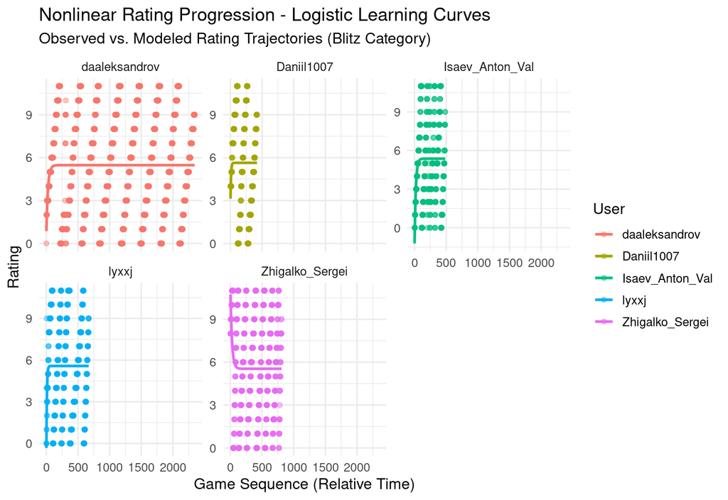

```r
predicted_curves <- nonlinear_models %>%
  select(user, term, estimate) %>%
  pivot_wider(names_from = term, values_from = estimate) %>%
  left_join(rating_nl_df, by = "user") %>%
  mutate(predicted = A - B * exp(-k * time_index))

ggplot(predicted_curves, aes(x = time_index, y = rating, color = user)) +
  geom_point(alpha = 0.4, size = 1.5) +
  geom_line(aes(y = predicted), linewidth = 1) +
  facet_wrap(~user, scales = "free_y") +
  labs(
    title = "Nonlinear Rating Progression - Logistic Learning Curves",
    subtitle = "Observed vs. Modeled Rating Trajectories (Blitz Category)",
    x = "Game Sequence (Relative Time)",
    y = "Rating",
    color = "User"
  ) +
  theme_minimal(base_size = 12)
```

### C.5 Learning Rate Analysis

```r
nonlinear_summary <- nonlinear_models %>%
  select(user, term, estimate) %>%
  pivot_wider(names_from = term, values_from = estimate) %>%
  mutate(
    ceiling_rating = round(A, 1),
    learning_rate = round(k, 4),
    rating_span = round(B, 1)
  ) %>%
  arrange(desc(learning_rate))

knitr::kable(
  nonlinear_summary,
  caption = "Nonlinear Model Parameters (Exponential Growth Model)",
  col.names = c("User", "Ceiling (A)", "Range (B)", "Learning Rate (k)", "Ceiling Rating", "Learning Rate", "Rating Span")
)
```

Nonlinear Model Parameters (Exponential Growth Model)

| User | Ceiling (A) | Range (B) | Learning Rate (k) | Ceiling Rating | Learning Rate | Rating Span |
| --- | --- | --- | --- | --- | --- | --- |
| lyxxj | 5.577287 | 6.633343 | 0.1163037 | 5.6 | 0.1163 | 6.6 |
| Daniil1007 | 5.637770 | 2.810038 | 0.1142074 | 5.6 | 0.1142 | 2.8 |
| Isaev_Anton_Val | 5.367098 | 6.937540 | 0.0517286 | 5.4 | 0.0517 | 6.9 |
| Zhigalko_Sergei | 5.537305 | -5.419421 | 0.0404173 | 5.5 | 0.0404 | -5.4 |
| daaleksandrov | 5.475299 | 4.799704 | 0.0395049 | 5.5 | 0.0395 | 4.8 |

> **Insights:**
> - `A` (Ceiling): Estimated maximum rating achievable.
> - `k` (Learning rate): How rapidly the player approaches their ceiling.
> - `B` (Range): Total expected improvement span.

### C.6 Bayesian Extension via `brms`

> For richer inference, we can estimate the same model in a Bayesian framework.

```r
library(brms)

# Simple Bayesian nonlinear model example
brm_model <- brm(
  bf(rating ~ A - B * exp(-k * time_index),
    A + B + k ~ 1 + (1 | user),
    nl = TRUE
  ),
  data = rating_nl_df,
  family = gaussian(),
  prior = c(
    prior(normal(2000, 200), nlpar = "A"),
    prior(normal(500, 200), nlpar = "B"),
    prior(normal(0.05, 0.02), nlpar = "k")
  ),
  cores = 4, iter = 2000, chains = 4
)
summary(brm_model)
```

[output not shown]

> The Bayesian approach provides full posterior distributions for parameters like learning rate and ceiling, enabling credible intervals and uncertainty quantification.

### C.7 Interpretation & Future Directions

**Empirical Takeaways:**

**Next Analytical Steps:**

1. Integrate `avg_win_rate` and `total_games` from `player_summary.csv` as covariates.
2. Use hierarchical nonlinear modeling (`nlme` or Bayesian `brms`) to estimate population-level learning behavior.
3. Extend across multiple categories (*Rapid*, *Blitz*, *Bullet*) for domain generalization.